# Part II - Ford GoBike Data Exploration (Slide Deck)

## by Baha abu khalil

## Investigation Overview

The goal of this presentation is to communicate key insights found during the data exploration of the Ford GoBike system data for February 2019. The analysis focuses on trip durations, user types, and gender, and highlights the usage patterns between Subscribers and Customers. We will present univariate, bivariate, and multivariate findings that help to understand the behavior of bike-sharing users.

## Dataset Overview

> The dataset includes information on individual bike trips taken in the Ford GoBike system during February 2019. It contains details such as trip duration, start and end station, user type, gender, and birth year of members.

## (Visualization 1)

This visualization shows the distribution of trip duration. The majority of trips are under 1000 seconds, with a few long trips as outliers.

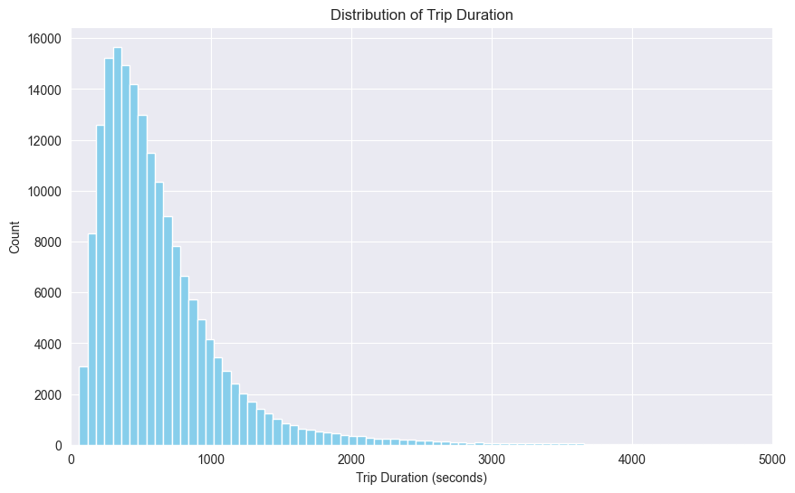

#### Question:

What is the distribution of trip durations?

#### Observation:

The majority of trips are under 1000 seconds, with a few long trips as outliers.

## (Visualization 2)

This visualization compares the trip duration between Subscribers and Customers. It highlights that Customers generally have longer trips compared to Subscribers.

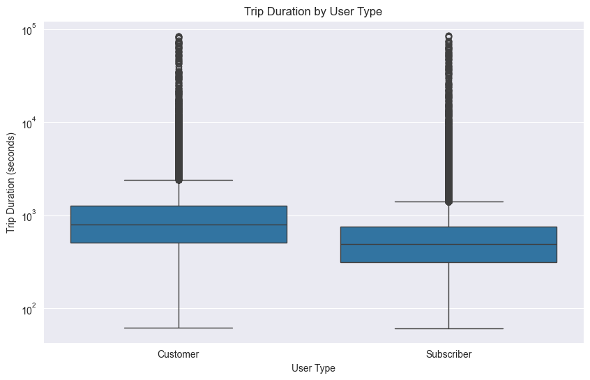

#### Question:

How does trip duration vary by user type (Subscriber vs Customer)?

#### Observation:

Customers generally have longer trip durations compared to Subscribers.

## (Visualization 3)

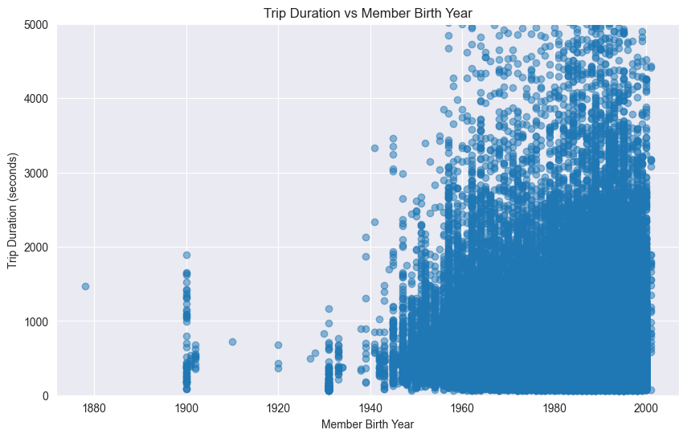

#### Question:

What is the relationship between trip duration and member birth year?

## (Visualization 4)

> This visualization displays the relationship between start and end stations as a heatmap. It reveals that certain station pairs have much higher trip frequencies, indicating popular routes in the dataset.

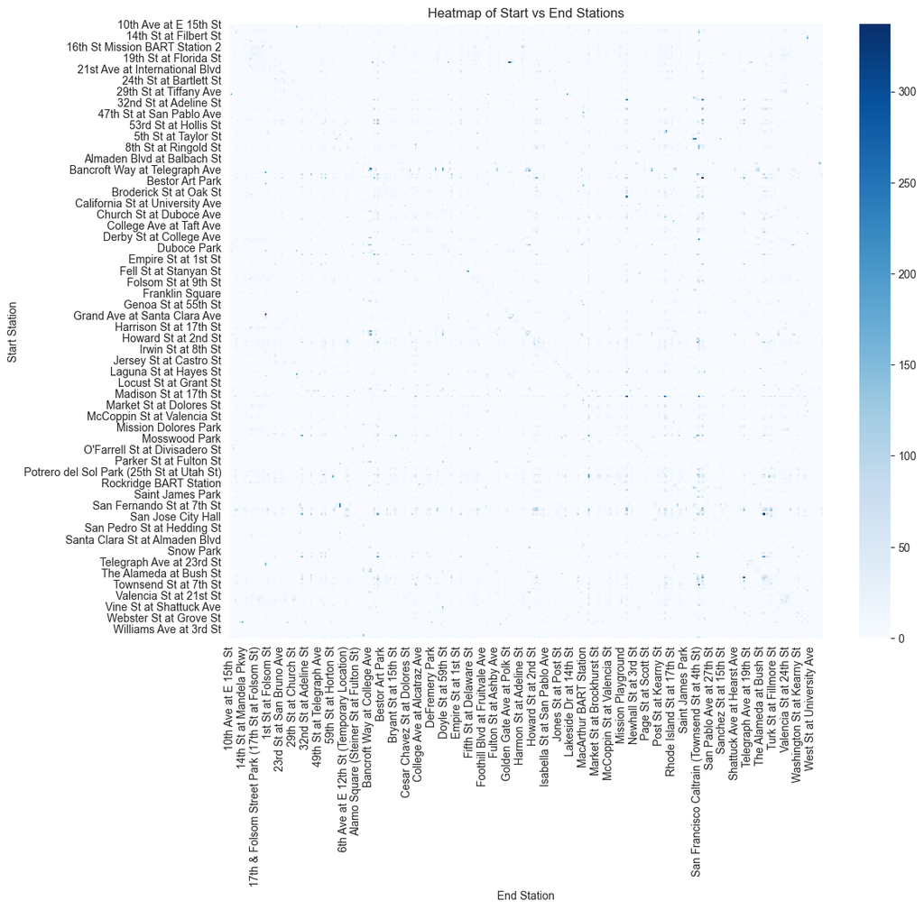

#### Question:

What is the relationship between start and end stations?

#### Observation:

Certain station pairs have much higher trip frequencies, indicating popular routes in the dataset.

## Visualization 5

> This visualization presents a FacetGrid of trip duration by user type and gender. It shows that males generally take more trips, and Customers tend to have longer trip durations across all genders.

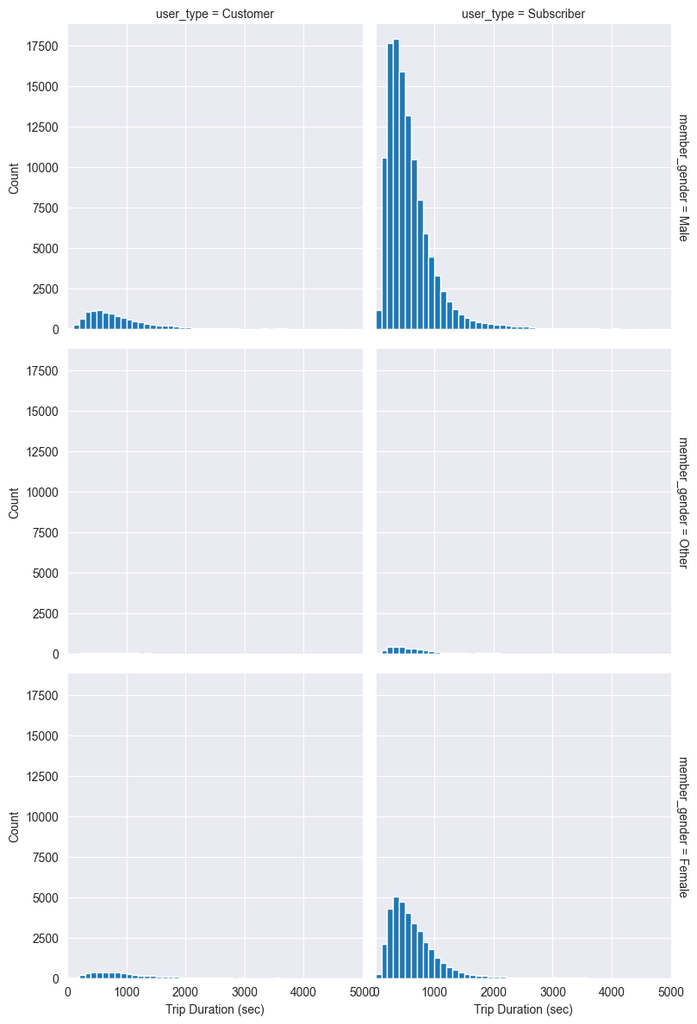

#### Question:

How does trip duration vary across user type and gender?

#### Observation:

Males make up the majority of trips for both user types. Customers tend to have longer trip durations compared to Subscribers. The distributions are right-skewed, with most trips under 1000 seconds.

## Visualization 6

> This visualization uses a boxplot to compare trip duration by user type and gender. It highlights differences in trip duration across gender groups within each user type.

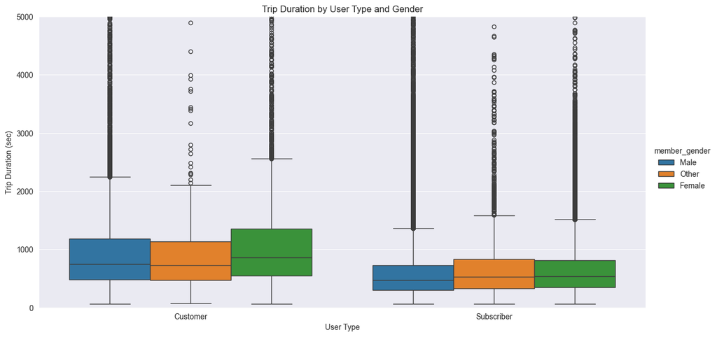

#### Question:

How does trip duration vary by user type and gender?

#### Observation:

Female customers tend to have longer trip durations compared to other groups. Gender provides extra context to understand trip duration differences between user types.

## Visualization 7

> This visualization is a barplot showing the count of users by type and gender. It shows the distribution of trips across the different combinations of user type and gender.

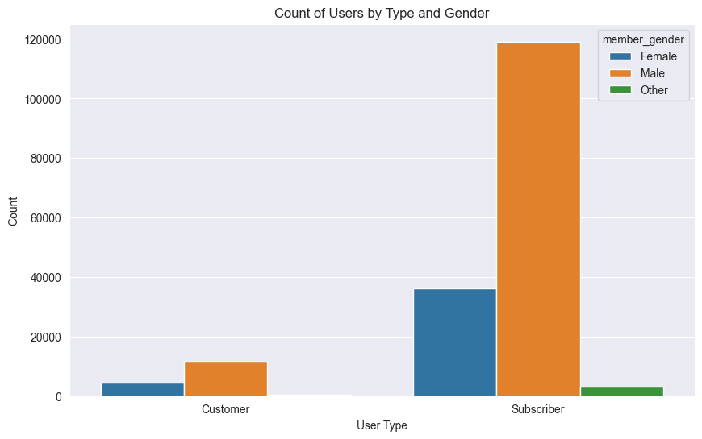

#### Question:

What is the distribution of users by type and gender?

#### Observation:

Subscribers form the majority of users, and within both user types, males make up the larger portion.